# ANLY-503 HW5

Elizabeth Shope

October 15, 2017

## PART 1: Wages Data

```r
# Read in data sets
    wages = read.csv('wages.csv', header=TRUE)

    # Load libraries
    library(stats)
    library(quantmod)
```

1. Use the Run Sequence, Lag Plot, Histogram, and QQnorm plot to determine if the distributions for the following three variables appear normal (Gaussian).
2. For variable(s) above with close to normal distributions - use interval estimation to estimate the parameters of the distribution.
3. For variable(s) above that do not appear normally distributed, what can you say about their distribution?

### Age

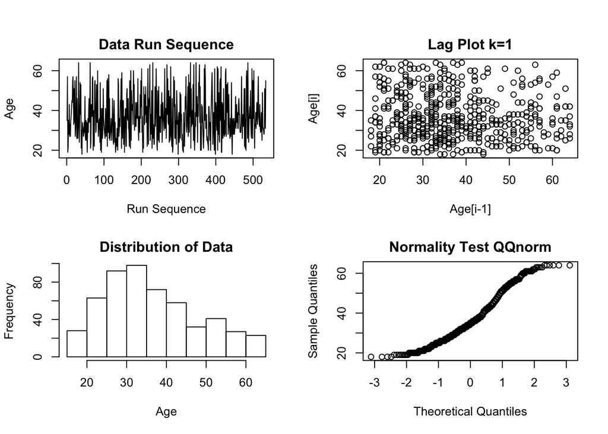

```r
# Set up plotting dimensions for 2x2
    par(mfrow = c(2, 2),
    oma = c(0, 0, 2, 0),
    mar = c(5.1, 4.1, 2.1, 2.1))

    # Create run sequence
    t = 1:length(wages$age)
    plot(t, wages$age, ylab="Age", xlab="Run Sequence", type="l", main="Data Run Sequence")

    # Create a lag plot
    plot(wages$age,Lag(wages$age, k=1),xlab="Age[i-1]",ylab="Age[i]", main="Lag Plot k=1")

    # Create histogram
    hist(wages$age, xlab="Age", main="Distribution of Data")

    # Create qqnorm plot
    qqnorm(wages$age,main="Normality Test QQnorm")
```

The Age variable does not appear to be totally normal – the histogram shows that it is somewhat right-skewed, and we see that the QQnorm plot is a bit curved. Also of note, there is no clear pattern in the data run sequence – it looks quite random. Out of the three variables, it is the closest to normal looking, so we can use interval estimation to estimate the parameters of the distribution.

```r
# Find mean of our age data
    avg_age = mean(wages$age)
    print(avg_age)
```

```
## [1] 36.83333
```

```r
# Find the standard deviation of our age data
    stdev_age=sd(wages$age)
    print(stdev_age)
```

```
## [1] 11.72657
```

```r
# Find error
    n = length(wages$age)
    error = qnorm(.975)*stdev_age/sqrt(n)
    print(error)
```

```
## [1] 0.9946002
```

```r
# Find upper and lower confidence intervals for mean age
    lowerCI = avg_age - error
    upperCI = avg_age + error
    paste("Lower CI for Mean Age: ", toString(round(lowerCI, 2)),
          ", Upper CI for Mean Age: ", toString(round(upperCI, 2)), sep = "")
```

```
## [1] "Lower CI for Mean Age: 35.84, Upper CI for Mean Age: 37.83"
```

```r
# Find upper and lower confidence intervals for standard deviation
    lowerCI_sd = sqrt((n-1)*stdev_age^2/qchisq(.975, df=533))
    upperCI_sd = sqrt((n-1)*stdev_age^2/qchisq(.025, df=533))
    paste("Lower CI for SD of Age: ", toString(round(lowerCI_sd, 2)),
          ", Upper CI for SD of Age: ", toString(round(upperCI_sd, 2)), sep = "")
```

```
## [1] "Lower CI for SD of Age: 11.06, Upper CI for SD of Age: 12.48"
```

### Wage

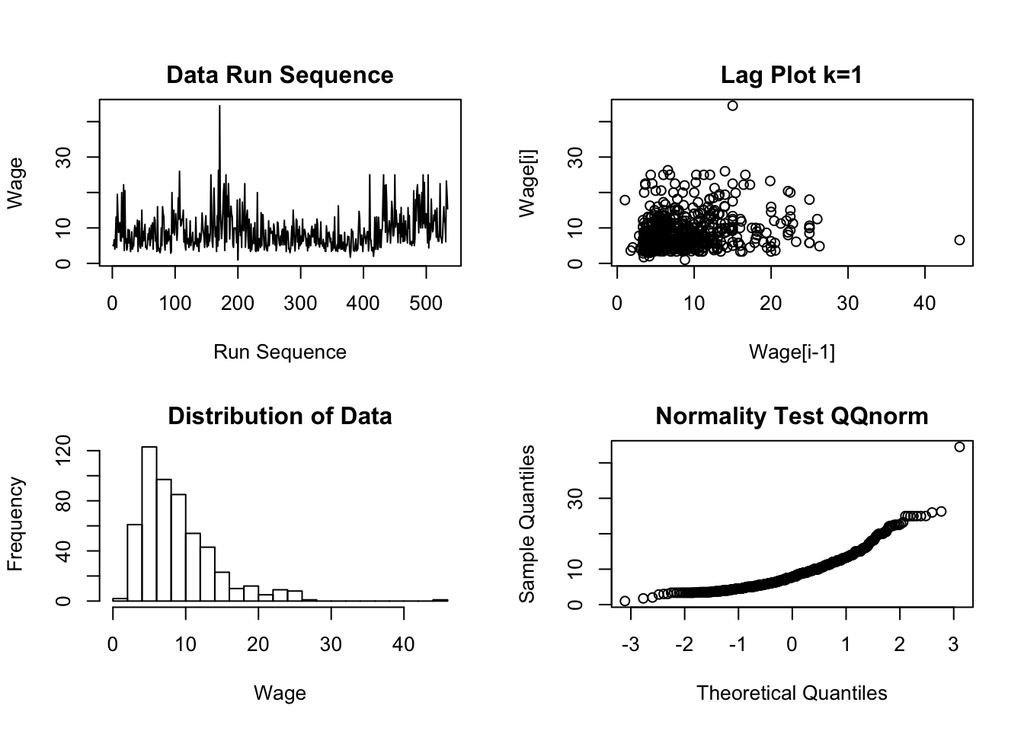

```r
# Set up plotting dimensions for 2x2
    par(mfrow = c(2, 2),
    oma = c(0, 0, 2, 0),
    mar = c(5.1, 4.1, 2.1, 2.1))

    # Create run sequence
    t = 1:length(wages$wage)
    plot(t, wages$wage, ylab="Wage", xlab="Run Sequence", type="l", main="Data Run Sequence")

    # Create a lag plot
    plot(wages$wage,Lag(wages$wage, k=1),xlab="Wage[i-1]",ylab="Wage[i]", main="Lag Plot k=1")

    # Create histogram
    hist(wages$wage, xlab="Wage", main="Distribution of Data", breaks=20)

    # Create qqnorm plot
    qqnorm(wages$wage,main="Normality Test QQnorm")
```

The Wage variable definitely does not appear to be normal – the histogram shows that it is very right-skewed, and all the plots show that there is a major outlier. The outlier makes it a little harder to read the QQnorm plot, but it appears to be somewhat curved, and that it would be even more curved if the outlier were removed. The data run sequence does not appear to be totally random; some sections of it appear to be higher than others.

The distribution looks like it may be a lognormal distribution. We can try log-transforming the data, and seeing if that transformation is then normal by once again looking at our set of four plots.

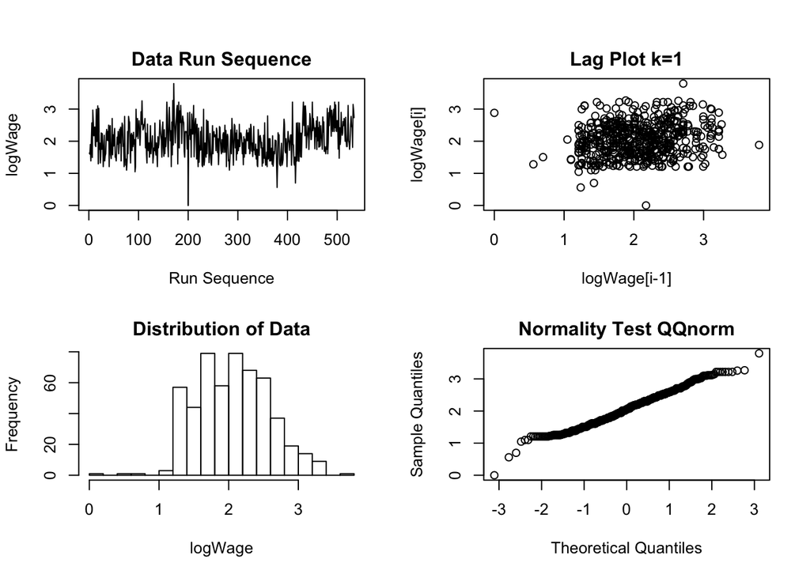

```r
# Log transform wage data
    logWage <- log(wages$wage)

    # Set up plotting dimensions for 2x2
    par(mfrow = c(2, 2),
    oma = c(0, 0, 2, 0),
    mar = c(5.1, 4.1, 2.1, 2.1))

    # Create run sequence
    t = 1:length(logWage)
    plot(t, logWage, ylab="logWage", xlab="Run Sequence", type="l", main="Data Run Sequence")

    # Create a lag plot
    plot(logWage,Lag(logWage, k=1),xlab="logWage[i-1]",ylab="logWage[i]", main="Lag Plot k=1")

    # Create histogram
    hist(logWage, xlab="logWage", main="Distribution of Data", breaks=14)

    # Create qqnorm plot
    qqnorm(logWage,main="Normality Test QQnorm")
```

This now looks pretty close to normal (with a few outliers), suggesting that the underlying distribution for the wages may in fact be lognormal.

### Experience

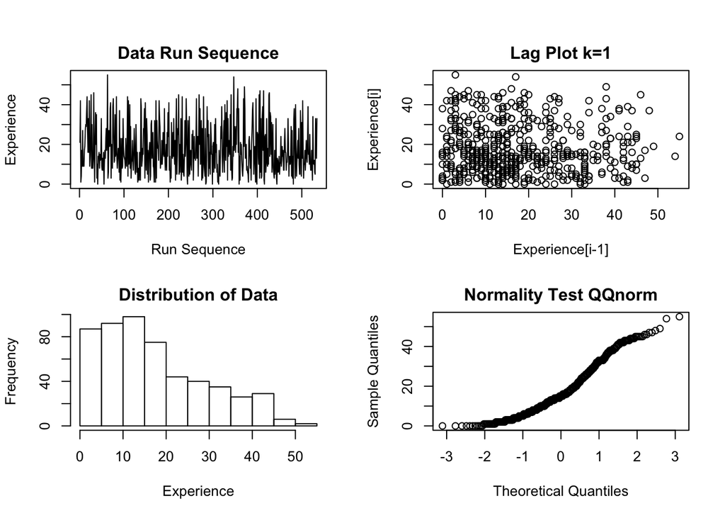

```r
# Set up plotting dimensions for 2x2
    par(mfrow = c(2, 2),
    oma = c(0, 0, 2, 0),
    mar = c(5.1, 4.1, 2.1, 2.1))

    # Create run sequence
    t = 1:length(wages$experience)
    plot(t, wages$experience, ylab="Experience", xlab="Run Sequence", type="l", main="Data Run Sequence")

    # Create a lag plot
    plot(wages$experience,Lag(wages$experience, k=1),
         xlab="Experience[i-1]",ylab="Experience[i]", main="Lag Plot k=1")

    # Create histogram
    hist(wages$experience, xlab="Experience", main="Distribution of Data")

    # Create qqnorm plot
    qqnorm(wages$experience,main="Normality Test QQnorm")
```

The experience data is also right-skewed, but unlike the wages data, the lower experience levels look almost uniform / just slightly increasing up to around 15 years of work experience before dropping off gradually. It’s not really clear if there is a standard statistical distribution that approximates this data well. It looks somewhat like a chi-squared distribution, and not too far off from a lognormal distribution, but I did some experimentation (not shown here), and neither really seem to fit the data too well. It’s also worth noting that the data run sequence and the lag plot don’t show any patterns.

4. Use a histogram and an independent samples t-test to determine if the Wage for males is significantly different than the Wage for females. What do the histograms suggest? Do the results from the t-test confirm the view from the visualization?

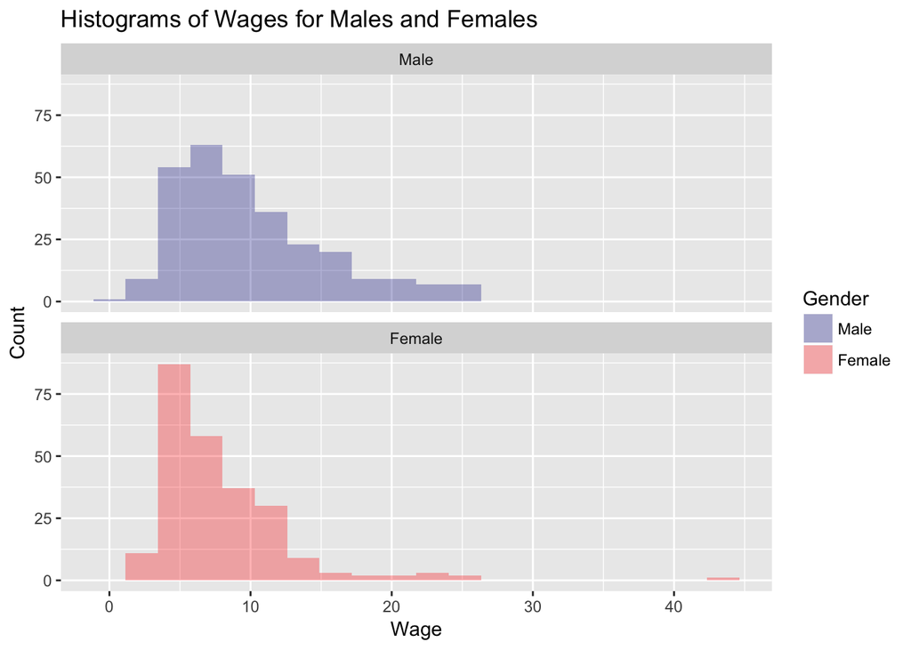

```r
# Load ggplot2
    library(ggplot2)

    # Pair genders with their numbers
    gender_names <- c("0" = "Male", "1" = "Female")

    # Make separate histograms for the males and females
    ggplot(data = wages, aes(wage, fill=factor(sex))) +
      geom_histogram(bins = 20, alpha=0.3) +
      facet_wrap(~sex, ncol = 1, labeller = as_labeller(gender_names)) +
      scale_fill_manual(values = c("1"="red", "0"="darkblue"), labels = c("Male", "Female")) +
      labs(x = "Wage", y = "Count", fill = "Gender", title = "Histograms of Wages for Males and Females")
```

Note that I looked up this data online, and determined that in fact, 0 = male and 1 = female. There definitely appear to be mroe females with some of the lower wage bars, and more males with some of the higher wage bars. Interestingly, the one major (high) wage outlier is a female. So I would say yes, that it appears that the wage for males is significantly different (higher) than the wage for females.

Now we can actually do the t-test and look at a few other statistics to check this.

```r
# Look at mean wage for men
    mean(wages$wage[wages$sex == 0])
```

```
## [1] 9.994913
```

```r
# Look at median wage for men
    median(wages$wage[wages$sex == 0])
```

```
## [1] 8.93
```

```r
# Look at mean wage for women
    mean(wages$wage[wages$sex == 1])
```

```
## [1] 7.878857
```

```r
# Look at median wage for women
    median(wages$wage[wages$sex == 1])
```

```
## [1] 6.8
```

```r
# Run independent samples t-test
    t.test(wages$wage ~ wages$sex)
```

```
##
    ##  Welch Two Sample t-test
    ##
    ## data:  wages$wage by wages$sex
    ## t = 4.8853, df = 530.55, p-value = 1.369e-06
    ## alternative hypothesis: true difference in means is not equal to 0
    ## 95 percent confidence interval:
    ##  1.265164 2.966949
    ## sample estimates:
    ## mean in group 0 mean in group 1
    ##        9.994913        7.878857
```

We find that the mean and median wage for males is higher than the mean and median wage for females. For the t-test our hypothesis is that the true difference in the mean wages between males and females is equal to 0, meaning that their wages are *not* different. Running the independent samples t-test, we get a t-value of 4.89 with 530.55 degrees of freedom, yielding a p-value of <0.0001. This means we have enough evidence to reject the null hypothesis and say that males are earning more than females. The 95% confidence interval indicates that the true difference between mean hourly wages for males and females likely lies between $1.27/hr and $2.97/hr. That adds up to a lot in the course of a year!

In short, our t-test statistically confirms what we saw visually in the histograms.

## Part 2: NFD and UFD data

1. Use the Run Sequence, Lag Plot, Histogram, and QQnorm plot to determine the distributions for the two datasets (each is univariate). Justify your answers.

### NFD Data

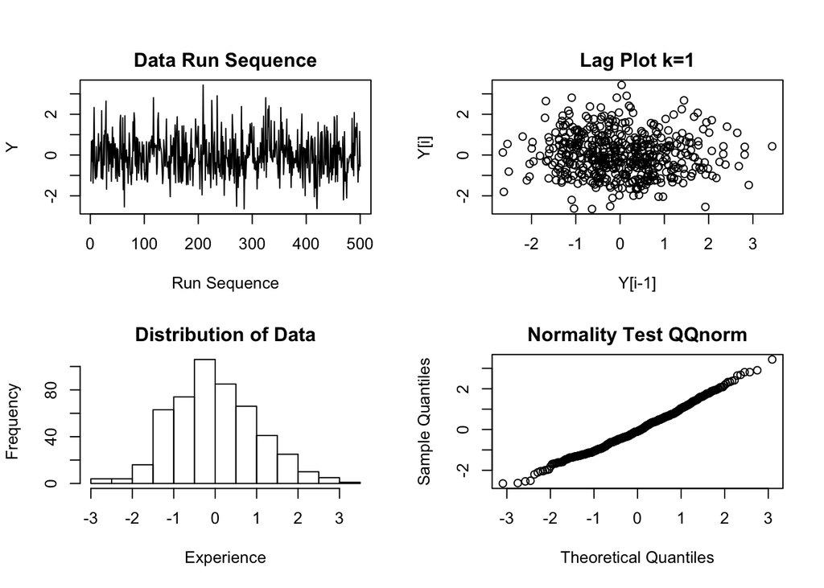

```r
# Read in NFD data in two ways: column by column, and row by row
    nfd_table <- read.table("NFD.txt")
    nfd_bycol <- c(nfd_table[,1], nfd_table[,2], nfd_table[,3], nfd_table[,4], nfd_table[,5])
    nfd_byrow <- scan("NFD.txt")

    ### CREATE THE WHOLE SEQUENCE USING THE BYCOL DATA
    # Set up plotting dimensions for 2x2
    par(mfrow = c(2, 2),
    oma = c(0, 0, 2, 0),
    mar = c(5.1, 4.1, 2.1, 2.1))

    # Create run sequence
    t = 1:length(nfd_bycol)
    plot(t, nfd_bycol, ylab="Y", xlab="Run Sequence", type="l", main="Data Run Sequence")

    # Create a lag plot
    plot(nfd_bycol,Lag(nfd_bycol, k=1), xlab="Y[i-1]",ylab="Y[i]", main="Lag Plot k=1")

    # Create histogram
    hist(nfd_bycol, xlab="Experience", main="Distribution of Data")

    # Create qqnorm plot
    qqnorm(nfd_bycol,main="Normality Test QQnorm")
```

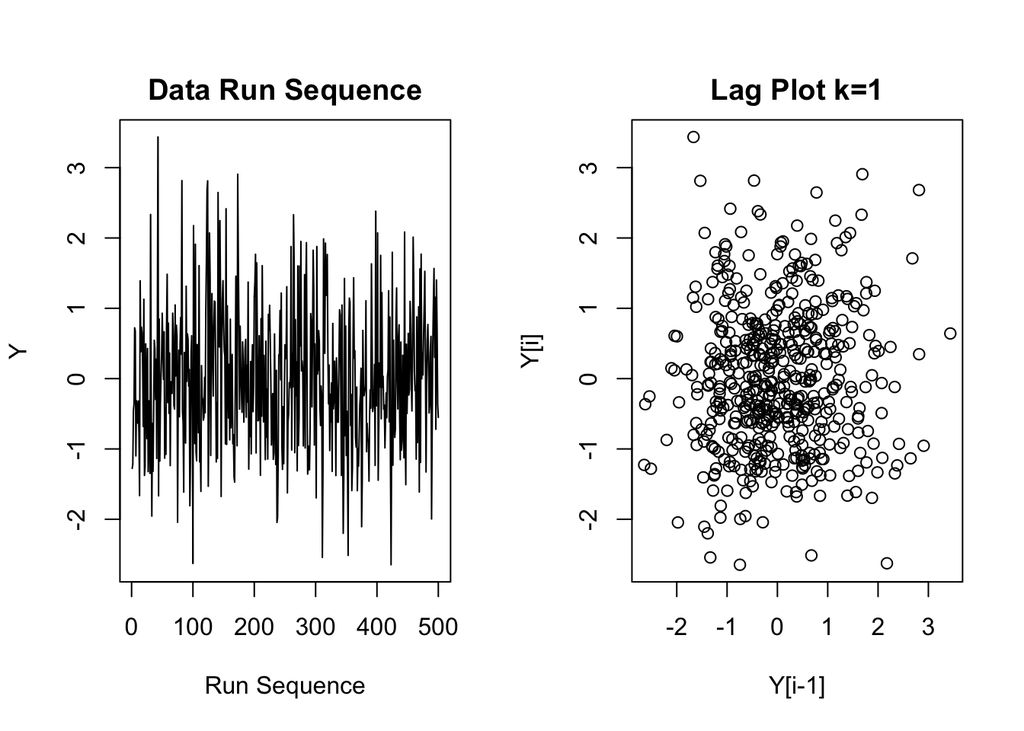

```r
### ALSO LOOK AT THE DATA RUN SEQUENCE AND LAG PLOT USING THE BYROW DATA
    # Set up plotting dimensions for 2x2
    par(mfrow = c(1, 2),
        oma = c(0, 0, 2, 0),
        mar = c(5.1, 4.1, 2.1, 2.1))

    # Create run sequence
    t = 1:length(nfd_byrow)
    plot(t, nfd_byrow, ylab="Y", xlab="Run Sequence", type="l", main="Data Run Sequence")

    # Create a lag plot
    plot(nfd_byrow, Lag(nfd_byrow, k=1), xlab="Y[i-1]",ylab="Y[i]", main="Lag Plot k=1")
```

```r
# Check mean and standard deviation of data
    mean(nfd_bycol)
```

```
## [1] -0.002936
```

```r
sd(nfd_bycol)
```

```
## [1] 1.021041
```

This appears to be a standard normal distribution. There are several signs suggest this is the underlying distribution:

- The histogram looks very much like a normal distribution
- The qqnorm plot is a very straight line
- Looking at the data run sequences and lag plots, there is no temporal pattern evident in the data (it looks quite random); this is true when the data is sorted by row or by column
- The mean is approximately 0, and the standard deviation is approximately 1

### UFD Data

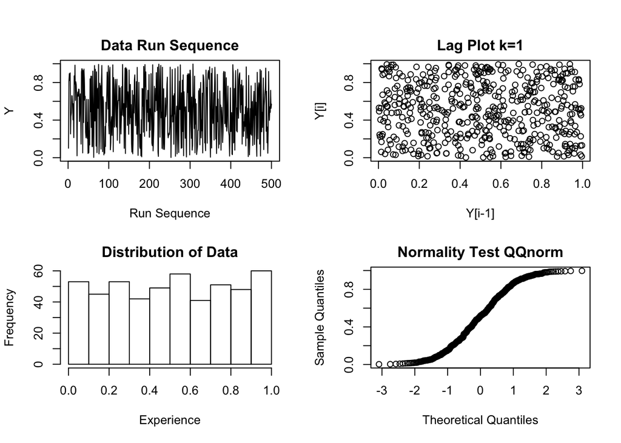

```r
# Read in UFD data in two ways: column by column, and row by row
    ufd_table <- read.table("UFD.txt")
    ufd_bycol <- c(ufd_table[,1], ufd_table[,2], ufd_table[,3], ufd_table[,4], ufd_table[,5])
    ufd_byrow <- scan("UFD.txt")

    ### CREATE THE WHOLE SEQUENCE USING THE BYCOL DATA
    # Set up plotting dimensions for 2x2
    par(mfrow = c(2, 2),
    oma = c(0, 0, 2, 0),
    mar = c(5.1, 4.1, 2.1, 2.1))

    # Create run sequence
    t = 1:length(ufd_bycol)
    plot(t, ufd_bycol, ylab="Y", xlab="Run Sequence", type="l", main="Data Run Sequence")

    # Create a lag plot
    plot(ufd_bycol,Lag(ufd_bycol, k=1), xlab="Y[i-1]",ylab="Y[i]", main="Lag Plot k=1")

    # Create histogram
    hist(ufd_bycol, xlab="Experience", main="Distribution of Data")

    # Create qqnorm plot
    qqnorm(ufd_bycol,main="Normality Test QQnorm")
```

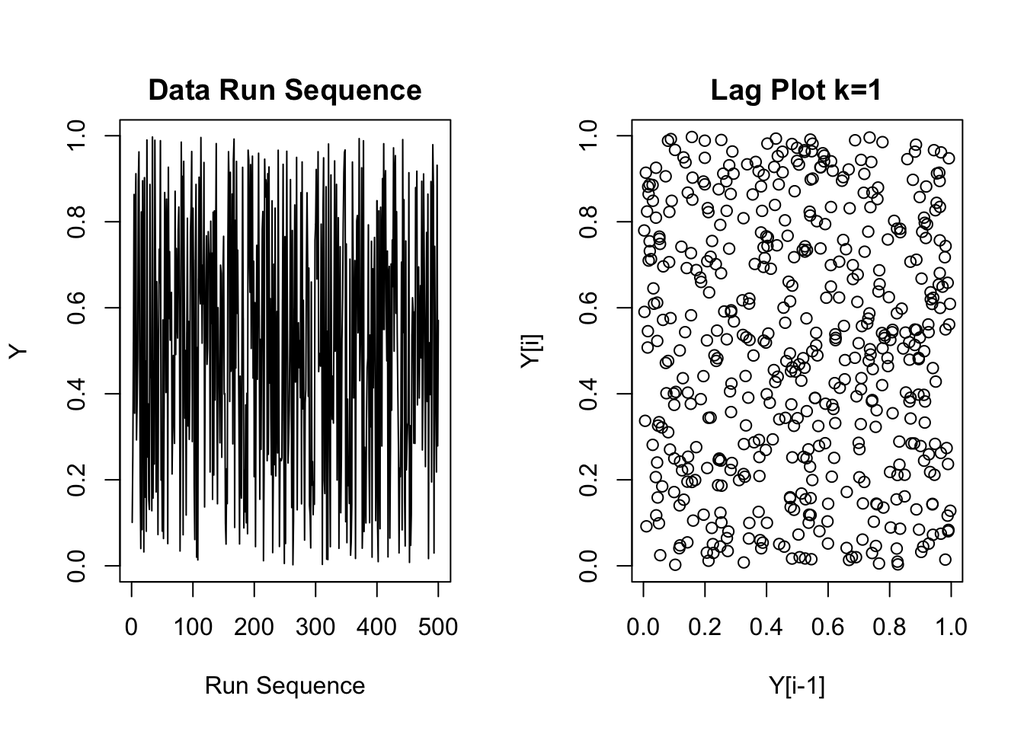

```r
### ALSO LOOK AT THE DATA RUN SEQUENCE AND LAG PLOT USING THE BYROW DATA
    # Set up plotting dimensions for 2x2
    par(mfrow = c(1, 2),
        oma = c(0, 0, 2, 0),
        mar = c(5.1, 4.1, 2.1, 2.1))

    # Create run sequence
    t = 1:length(ufd_byrow)
    plot(t, ufd_byrow, ylab="Y", xlab="Run Sequence", type="l", main="Data Run Sequence")

    # Create a lag plot
    plot(ufd_byrow, Lag(ufd_byrow, k=1), xlab="Y[i-1]",ylab="Y[i]", main="Lag Plot k=1")
```

```r
# Check mean and standard deviation of data
    mean(ufd_bycol)
```

```
## [1] 0.5078304
```

```r
sd(ufd_bycol)
```

```
## [1] 0.2943252
```

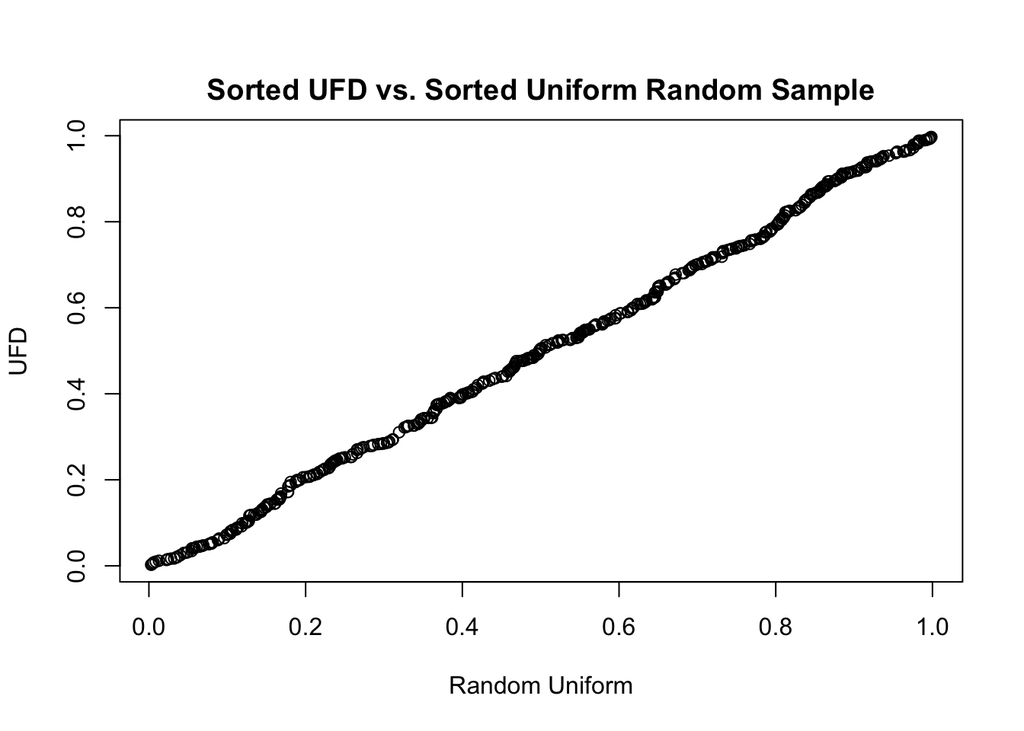

```r
# Create uniform random sample
    # Plot sorted uniform random sample against the sorted ufd_bycol
    par(mfrow = c(1,1))
    plot(sort(runif(500)), sort(ufd_bycol),
         xlab = "Random Uniform", ylab="UFD", main = "Sorted UFD vs. Sorted Uniform Random Sample")
```

This appears to be a uniform distribution between 0 and 1. The evidence for this is:

- The histogram looks quite uniform with most of the bars of equal height
- Once again, looking at the data run sequences and lag plots, there is no temporal pattern evident in the data (it looks quite random); this is true when the data is sorted by row or by column
- For a 0-1 uniform distribution, the mean should be 0.5, and the standard deviation should be $\frac{1}{\sqrt{12}} \approx 0.29$; the mean and standard deviation of the data is approximately equal to this mean and standard deviation
- Plotting the sorted UFD against a sorted random uniform sample, we get a straight line, once again suggesting that this is a uniform distribution